# PCA_Ppor_Sym

Veronica Radice

03/05/2021

# Principal Compoment Analysis

# *Porites porites*

## Symbionts

### National Park color palettes

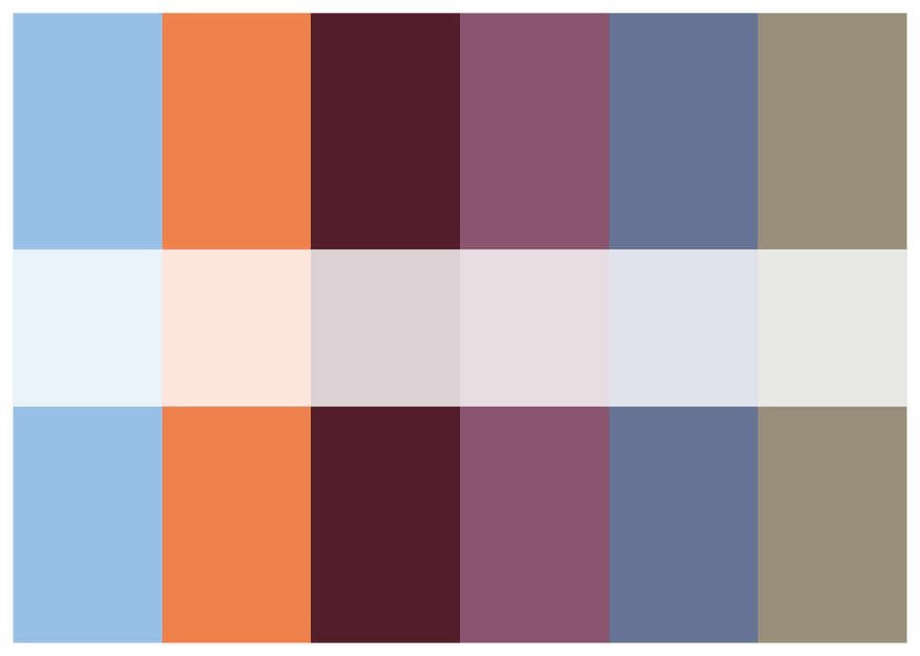

```r
# check palette
pal <- park_palette("Arches")
pal
```

```r
# select palette
chosen.palette <- palette(park_palette("Arches")) #BlueRidgePkwy
```

```r
alt.palette <- c("#8c510a", "#d8b365", "#f6e8c3", "#c7eae5", "#5ab4ac", "#01665e")
```

### Set working directory

```r
setwd("~/Documents/Rprojects/postdoc\ Rprojects/ODU_postdoc_Rprojects/Paper_Ojo_gene-expression/Porites_porites/symbiont/")
```

## Import metadata

```r
meta <- read.csv("~/Documents/Rprojects/postdoc\ Rprojects/ODU_postdoc_Rprojects/Paper_Ojo_gene-expression/Porites_porites/Porites_porites_Year-2_metadata.csv", header=TRUE, row.names=1)

# Remove all samples that were transplanted to the Destination Ojo.Norte
# There is no control site for Norte Ojo
# For now, we are focused on samples transplanted to Laja Control or Laja Ojo sites
# This is consistent with analyses for the other 2 species in the experiment
# Also, group sample size is too small for Ojo.Norte destination

meta <- subset(meta, Destination_name != "Ojo.Norte")
```

```r
meta$Destination_type <- revalue(meta$Destination_type, c("control" = "Control", "ojo" = "Ojo"))

meta <- meta %>% unite(group, Origin_type, Destination_type, sep = ".", remove = FALSE)


meta[sapply(meta, is.character)] <- lapply(meta[sapply(meta, is.character)],
                                       as.factor)
# Colony_ID is equivalent to genotype
meta$Colony_ID <- as.factor(meta$Colony_ID)

meta <- meta %>% unite(colony_sample, Origin_type, Destination_type, Colony_ID, id, sep = ".", remove = FALSE)

levels(meta$group)
```

```
## [1] "Reef.Control" "Reef.Ojo"
```

### select relevant metadata

```r
meta <- dplyr::select(meta, Colony_ID, group, Origin_name, Origin_type, Destination_name, Destination_type, pH_Destination, colony_sample)
```

### Remove sample with >85% of null/zero counts

As in DESeq2 analysis

```r
drop <- c("R_057_C_Pp_yr2", "R_054_C_Pp_yr2" , "R_058_La_Pp_yr2")

meta <- meta[!(row.names(meta) %in% drop),]
meta <- droplevels(meta)
dim(meta)
```

```
## [1] 7 8
```

### data summary

```r
meta %>%
  group_by(group) %>%
  dplyr::summarise(count = n())
```

```
## # A tibble: 2 x 2
##   group        count
## * <fct>        <int>
## 1 Reef.Control     5
## 2 Reef.Ojo         2
```

# Normalized gene count data

Import normalized gene count data (from function counts(dds, normalized=TRUE)) –> Overall expression

```r
norm.genes <- readRDS(file = "counts_normalized_Ppor_symbiont.rds")
norm.genes <- as.data.frame.array(norm.genes)
```

### Check that sample names match in both files

```r
all(colnames(norm.genes) %in% rownames(meta))
```

```
## [1] TRUE
```

```r
all(colnames(norm.genes) == rownames(meta))
```

```
## [1] TRUE
```

```r
# If your data did not match, you could use the match() function to rearrange them to be matching.
```

# Import transformed counts

```r
counts.transformed.vst <- readRDS(file = "counts_vst.BlindFalse_Ppor_symbiont.rds")
```

# Differentially expressed genes

Import table for *each pairwise group* of Differentially Expressed gene list (pvalue < 0.05) from normalized gene count data.

```r
de.genes.RO_RC <- readRDS(file = "Ppor_symbiont_RO_RC_pval.05.rds")
de.genes.RO_RC <- as.data.frame(de.genes.RO_RC)
dim(de.genes.RO_RC)
```

```
## [1] 262   7
```

# Principal Component Analysis (PCA)

## Total expression

By default the function uses the top 500 most variable genes. You can change this by adding the ntop argument and specifying how many genes you want to use to draw the plot.

ntop  
- number of top genes to use for principal components, selected by highest row variance

## Total expression - by transplant treatment group

ntop = 1000

```
## Too few points to calculate an ellipse
```

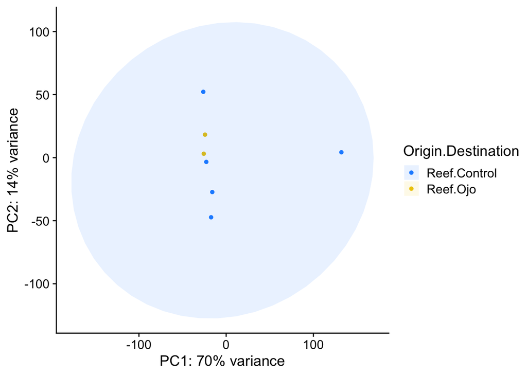

```r
# save plot
#pdf("Ppor_symbiont_PCA_total-exp_group.pdf")

pcadata = DESeq2::plotPCA(counts.transformed.vst, intgroup = c("group"), returnData = TRUE)
percentVar = round(100 * attr(pcadata, "percentVar"))
pca = prcomp(t(assay(counts.transformed.vst)), center = TRUE, scale. = FALSE)

plot <- DESeq2::plotPCA(counts.transformed.vst, returnData = TRUE, intgroup = c("group"), ntop = 1000) %>%
      ggplot(aes(x = PC1, y = PC2)) +
      geom_point(aes(color = group), size = 1.3) +
      stat_ellipse(geom = "polygon", alpha = 1/10, aes(fill = group)) +
      scale_color_manual(values = c("dodgerblue", "gold2", "#163343", "firebrick", "forestgreen", "bisque3")) + #chosen.palette
      scale_fill_manual(values = c("dodgerblue", "gold2", "#163343", "firebrick", "forestgreen", "bisque3")) +
      xlab(paste0("PC1: ",percentVar[1],"% variance")) +
      ylab(paste0("PC2: ",percentVar[2],"% variance")) +
      labs(color = "Origin.Destination", fill = "Origin.Destination") +
      theme_cowplot()

plot
```

```r
#dev.off()

# good palette
# c("gold2", "forestgreen", "black", "firebrick", "darkorange1", "#847CA3") - favorite
# c("forestgreen", "black", "#F2D56F", "firebrick", "#F4A65E", "#847CA3")
# c("#F2D56F", "forestgreen", "black", "firebrick", "#F4A65E", "#847CA3") reordered

# Arches
# "#EC8FA3" "#FCBA65" "#FAECCF" "#8D7F99" "#8C9D57" "#163343"

# Arches reordered
# "#EC8FA3" "#FCBA65" "#163343" "#8D7F99" "#8C9D57" "#FAECCF"
# c("#EC8FA3", "#FCBA65", "#163343", "cornflowerblue", "#8C9D57", "bisque3") - favorite
# c("dodgerblue", "gold2", "#163343", "firebrick", "forestgreen", "bisque3") - new fave
# "#8C9D57" "bisque3" "#163343" "cornflowerblue" "#EC8FA3" "#FCBA65" - also good

# reordered
# c("#1A1237", "#E45A5A", "#80792B", "#F2D56F", "#F4A65E", "#847CA3")

#"#847CA3" "#E45A5A" "#F4A65E" "#80792B" "#F2D56F" "#1A1237"
```

save plot

```r
# save plot
pdf("Ppor_symbiont_PCA_total-exp_group.pdf")

pcadata = DESeq2::plotPCA(counts.transformed.vst, intgroup = c("group"), returnData = TRUE)
percentVar = round(100 * attr(pcadata, "percentVar"))
pca = prcomp(t(assay(counts.transformed.vst)), center = TRUE, scale. = FALSE)

plot <- DESeq2::plotPCA(counts.transformed.vst, returnData = TRUE, intgroup = c("group"), ntop = 1000) %>%
      ggplot(aes(x = PC1, y = PC2)) +
      geom_point(aes(color = group), size = 1.3) +
      stat_ellipse(geom = "polygon", alpha = 1/10, aes(fill = group)) +
      scale_color_manual(values = c("dodgerblue", "gold2", "#163343", "firebrick", "forestgreen", "bisque3")) + #chosen.palette
      scale_fill_manual(values = c("dodgerblue", "gold2", "#163343", "firebrick", "forestgreen", "bisque3")) +
      xlab(paste0("PC1: ",percentVar[1],"% variance")) +
      ylab(paste0("PC2: ",percentVar[2],"% variance")) +
      labs(color = "Origin.Destination", fill = "Origin.Destination") +
      theme_cowplot()

plot
```

```
## Too few points to calculate an ellipse
```

```r
dev.off()
```

for comparison, ntop = 500 (similar)

```
## Too few points to calculate an ellipse
```

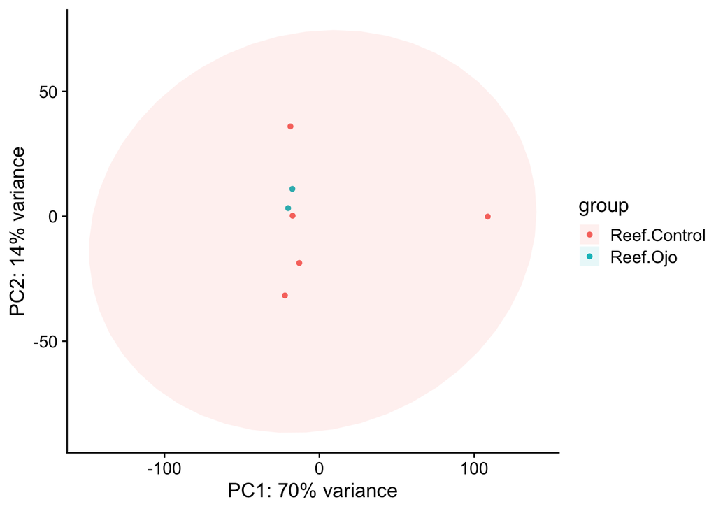

```r
pcadata = DESeq2::plotPCA(counts.transformed.vst, intgroup = c("group"), returnData = TRUE)
percentVar = round(100 * attr(pcadata, "percentVar"))
pca = prcomp(t(assay(counts.transformed.vst)), center = TRUE, scale. = FALSE)

plot <- DESeq2::plotPCA(counts.transformed.vst, returnData = TRUE, intgroup = c("group"), ntop = 500) %>%
      ggplot(aes(x = PC1, y = PC2)) +
      geom_point(aes(colour = group), size = 1.3) +
      stat_ellipse(geom = "polygon", alpha = 1/10, aes(fill = group)) +
      xlab(paste0("PC1: ",percentVar[1],"% variance")) +
      ylab(paste0("PC2: ",percentVar[2],"% variance")) +
      theme_cowplot()

plot
```

test alternate colors

```
## Too few points to calculate an ellipse
```

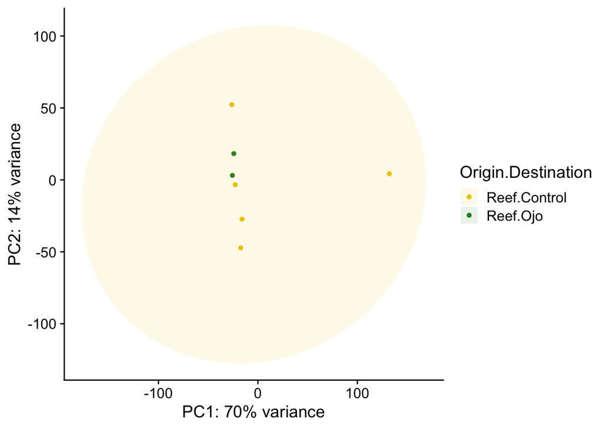

```r
pcadata = DESeq2::plotPCA(counts.transformed.vst, intgroup = c("group"), returnData = TRUE)
percentVar = round(100 * attr(pcadata, "percentVar"))
pca = prcomp(t(assay(counts.transformed.vst)), center = TRUE, scale. = FALSE)

plot <- DESeq2::plotPCA(counts.transformed.vst, returnData = TRUE, intgroup = c("group"), ntop = 1000) %>%
      ggplot(aes(x = PC1, y = PC2)) +
      geom_point(aes(color = group), size = 1.3) +
      stat_ellipse(geom = "polygon", alpha = 1/10, aes(fill = group)) +
      scale_color_manual(values = c("gold2", "forestgreen", "black", "firebrick", "darkorange1", "#847CA3")) + #chosen.palette
      scale_fill_manual(values = c("gold2", "forestgreen", "black", "firebrick", "darkorange1", "#847CA3")) +
      xlab(paste0("PC1: ",percentVar[1],"% variance")) +
      ylab(paste0("PC2: ",percentVar[2],"% variance")) +
      labs(color = "Origin.Destination", fill = "Origin.Destination") +
      theme_cowplot()

plot
```

# Total expression - Colony ID & Sample ID

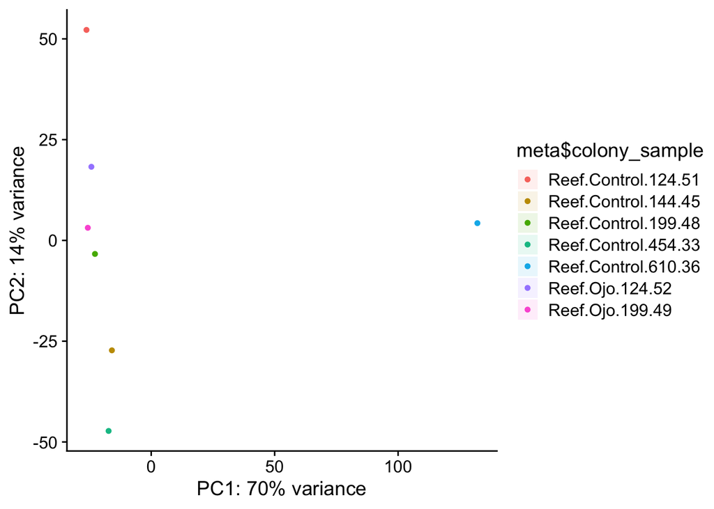

```r
pcadata = DESeq2::plotPCA(counts.transformed.vst, intgroup = c("group"), returnData = TRUE)
percentVar = round(100 * attr(pcadata, "percentVar"))
pca = prcomp(t(assay(counts.transformed.vst)), center = TRUE, scale. = FALSE)

plot <- DESeq2::plotPCA(counts.transformed.vst, returnData = TRUE, intgroup = c("group"), ntop = 1000) %>%
      ggplot(aes(x = PC1, y = PC2)) +
      geom_point(aes(color = meta$colony_sample), size = 1.3) +
      stat_ellipse(geom = "polygon", alpha = 1/10, aes(fill = meta$colony_sample)) +
      xlab(paste0("PC1: ",percentVar[1],"% variance")) +
      ylab(paste0("PC2: ",percentVar[2],"% variance")) +
      theme_cowplot()

plot
```

# Total expression - Colony (genotype)

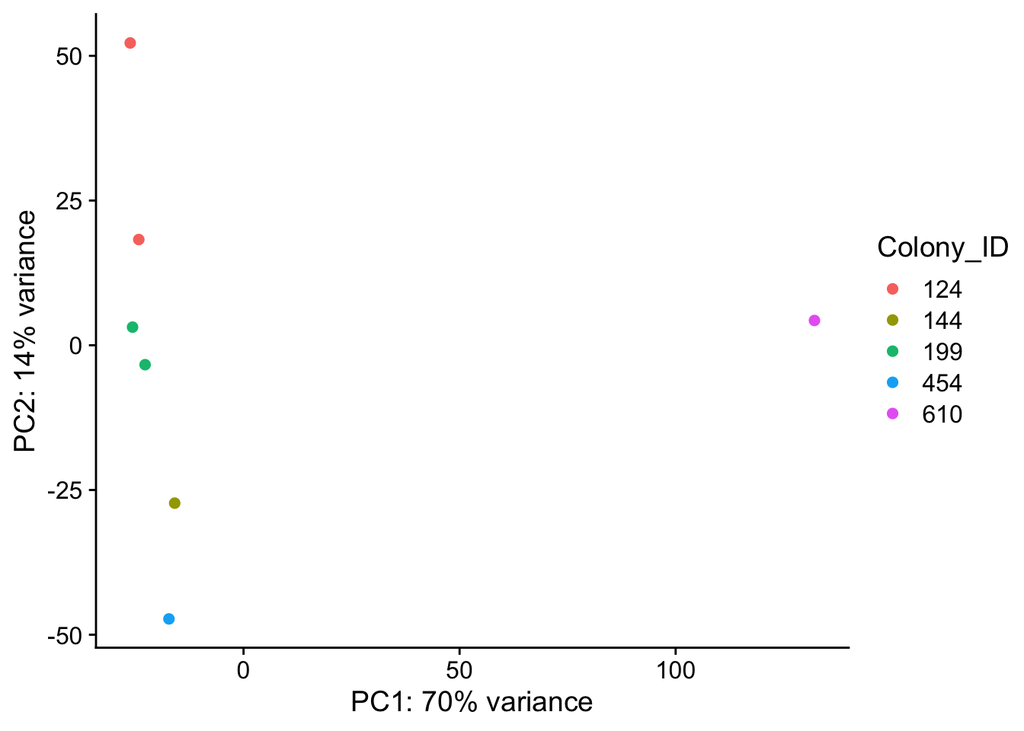

```r
pcadata = DESeq2::plotPCA(counts.transformed.vst, intgroup = c("Colony_ID"), returnData = TRUE)
percentVar = round(100 * attr(pcadata, "percentVar"))
pca = prcomp(t(assay(counts.transformed.vst)), center = TRUE, scale. = FALSE)

plot <- DESeq2::plotPCA(counts.transformed.vst, returnData = TRUE, intgroup = c("Colony_ID"), ntop = 1000) %>%
      ggplot(aes(x = PC1, y = PC2)) +
      geom_point(aes(colour = Colony_ID), size = 2) +
      xlab(paste0("PC1: ",percentVar[1],"% variance")) +
      ylab(paste0("PC2: ",percentVar[2],"% variance")) +
      labs(color = "Colony_ID", fill = "Colony_ID") +
      theme_cowplot()

plot
```

# Principal Component Analysis (PCA)

## Pairwise group contrasts

Significantly different genes (pvalue < 0.05) between treatment groups for pairwise comparisons

## PCA - all indiv. - RO_RC

```r
# extract row names from DE gene list
rownames(de.genes.RO_RC) <- de.genes.RO_RC[,1]

sigChanges <- rownames(de.genes.RO_RC)[de.genes.RO_RC$pvalue < 0.05 & !is.na(de.genes.RO_RC$pvalue)]

counts_de <- counts.transformed.vst[rownames(counts.transformed.vst) %in% sigChanges,]

dim(counts_de)
```

```
## [1] 262   7
```

```
## Too few points to calculate an ellipse
```

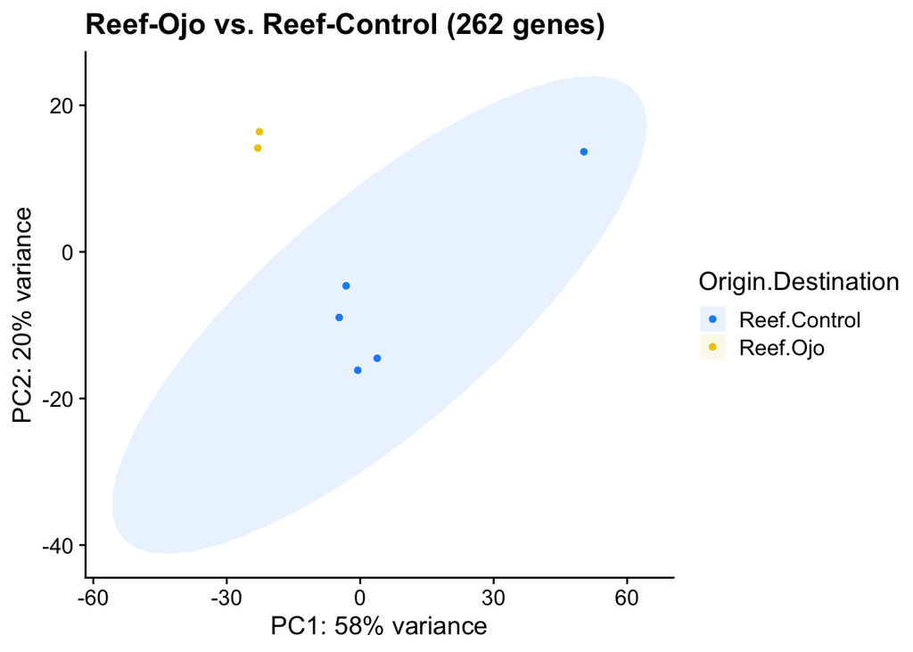

```r
pcadata = DESeq2::plotPCA(counts_de, intgroup = c("group"), returnData = TRUE)
percentVar = round(100 * attr(pcadata, "percentVar"))
pca = prcomp(t(assay(counts_de)), center = TRUE, scale. = FALSE)

plot <- DESeq2::plotPCA(counts_de, returnData = TRUE, intgroup = c("group")) %>%
      ggplot(aes(x = PC1, y = PC2)) +
      geom_point(aes(color = group), size = 1.3) +
      stat_ellipse(geom = "polygon", alpha = 1/10, aes(fill = group)) +
      scale_color_manual(values = c("dodgerblue", "gold2", "#163343", "firebrick", "forestgreen", "bisque3")) + #chosen.palette
      scale_fill_manual(values = c("dodgerblue", "gold2", "#163343", "firebrick", "forestgreen", "bisque3")) +
      xlab(paste0("PC1: ",percentVar[1],"% variance")) +
      ylab(paste0("PC2: ",percentVar[2],"% variance")) +
      labs(title = "Reef-Ojo vs. Reef-Control (262 genes)") +
      labs(color = "Origin.Destination", fill = "Origin.Destination") +
      theme_cowplot()

plot
```

save plot

```r
# save plot
pdf("Ppor_symbiont_PCA_RO_RC_all-indiv.pdf")

pcadata = DESeq2::plotPCA(counts_de, intgroup = c("group"), returnData = TRUE)
percentVar = round(100 * attr(pcadata, "percentVar"))
pca = prcomp(t(assay(counts_de)), center = TRUE, scale. = FALSE)

plot <- DESeq2::plotPCA(counts_de, returnData = TRUE, intgroup = c("group")) %>%
      ggplot(aes(x = PC1, y = PC2)) +
      geom_point(aes(color = group), size = 1.3) +
      stat_ellipse(geom = "polygon", alpha = 1/10, aes(fill = group)) +
      scale_color_manual(values = c("dodgerblue", "gold2", "#163343", "firebrick", "forestgreen", "bisque3")) + #chosen.palette
      scale_fill_manual(values = c("dodgerblue", "gold2", "#163343", "firebrick", "forestgreen", "bisque3")) +
      xlab(paste0("PC1: ",percentVar[1],"% variance")) +
      ylab(paste0("PC2: ",percentVar[2],"% variance")) +
      labs(title = "Reef-Ojo vs. Reef-Control (262 genes)") +
      labs(color = "Origin.Destination", fill = "Origin.Destination") +
      theme_cowplot()

plot
```

```
## Too few points to calculate an ellipse
```

```r
dev.off()
```

check

```r
dim(counts_de)
```

```
## [1] 262   7
```

```r
dim(de.genes.RO_RC)
```

```
## [1] 262   7
```

```r
colnames(counts_de)
```

```
## [1] "R_033_C_Pp_yr2"  "R_036_C_Pp_yr2"  "R_045_C_Pp_yr2"  "R_048_C_Pp_yr2"
## [5] "R_049_La_Pp_yr2" "R_051_C_Pp_yr2"  "R_052_La_Pp_yr2"
```

# PERMANOVA

### transpose gene table

```r
norm.genes.t <- data.table::transpose(norm.genes, keep.names = "rn")

rownames(norm.genes.t) <- norm.genes.t[,1]

norm.genes.t <- norm.genes.t[,-1]

dim(norm.genes.t)
```

```
## [1]     7 10334
```

### Make distance matrix

```r
dist_overall <- vegdist(norm.genes.t, method="bray")
```

## PERMANOVA - Total gene expression (normalized)

```r
permanova_overall.interaction <- adonis(dist_overall ~ group, data = meta, permutations=9999, na.rm = TRUE)
```

```
## 'nperm' >= set of all permutations: complete enumeration.
```

```
## Set of permutations < 'minperm'. Generating entire set.
```

```r
permanova_overall.interaction
```

```
##
## Call:
## adonis(formula = dist_overall ~ group, data = meta, permutations = 9999,      na.rm = TRUE)
##
## Permutation: free
## Number of permutations: 5039
##
## Terms added sequentially (first to last)
##
##           Df SumsOfSqs MeanSqs F.Model      R2  Pr(>F)
## group      1   0.29714 0.29714  1.8389 0.26889 0.09524 .
## Residuals  5   0.80792 0.16158         0.73111
## Total      6   1.10506                 1.00000
## ---
## Signif. codes:  0 '***' 0.001 '**' 0.01 '*' 0.05 '.' 0.1 ' ' 1
```

(Alternate) Make distance matrix and run PERMANOVA together in *one function* adonis(norm.genes.t ~ group, data = meta, method = “bray”, permutations=9999, na.rm = TRUE)

## Pairwise PERMANOVA

This is a wrapper function for multilevel pairwise comparison using adonis() from package ‘vegan’. The function returns adjusted p-values using p.adjust(), default is ‘bonferroni’. - ‘arg’ should be one of “holm”, “hochberg”, “hommel”, “bonferroni”, “BH”, “BY”, “fdr”, “none”

## Pairwise PERMANOVA - Group

```r
pairwise.adonis(dist_overall, factors = meta$group,  p.adjust.m = 'fdr', perm = 9999)
```

```
## 'nperm' >= set of all permutations: complete enumeration.
```

```
## Set of permutations < 'minperm'. Generating entire set.
```

```
##                      pairs Df SumsOfSqs  F.Model        R2   p.value p.adjusted
## 1 Reef.Control vs Reef.Ojo  1 0.2971394 1.838919 0.2688904 0.0952381  0.0952381
##   sig
## 1
```

```r
# sim.function = 'vegdist' (default)
# sim.method = 'bray' (default)
## calculate the similarity matrix. Ignored if x is a distance matrix)
```